# SDO6: English versus Chinese

- Show All Code
- Hide All Code
- View Source

Paired scores and answer distributions for Section 3.2

Author

Analysis of the MS_AAI_ToM data

Published

October 25, 2026

## 1 Which test answers the question?

**Use a two-sided paired t test across models for the main comparison.** These are the same models answering in two languages, rather than separate groups of English and Chinese models. For each model, calculate its mean reverse-keyed SDO6 score in each language and compare the 27 Chinese-minus-English differences with zero. This reproduces the test already quoted in Section 3.2.

A two-way ANOVA is unnecessary for this hypothesis. There is one factor of interest, language, with two repeated levels. A one-factor repeated-measures ANOVA on the same model means gives exactly the same result: F = t squared. A language-by-run ANOVA would additionally ask whether the language difference varies by run number. Run labels identify replicate sets, not a chronological sequence for these parallel requests; that interaction is a different question.

**The answer percentages in Fig. 2A are a second question.** A paired t test tests the mean score, not equality of all seven response frequencies. Below, an additional test uses Pearson’s chi-square statistic but obtains its P value by swapping the two language profiles within entire models. All items and runs from a model move together. An ordinary pooled `chisq.test()` P value would ignore this dependence; `simulate.p.value = TRUE` does not repair it.

The main score test is the existing H1 analysis. The added distribution and response-feature tests are **exploratory follow-ups**, with Holm adjustment across those five tests. Do not select a test according to which P value is smallest.

## 2 Setup and data checks

Run this file with RStudio’s **Render** button or, from the repository root:

```bash
quarto render Analysis_script/10_sdo6_language_tests.qmd --output-dir ../Analysis_output/Language_comparison
```

Required packages: `dplyr`, `tidyr`, `readr`, `ggplot2`, and `knitr`. The file does not install packages or rerun the existing large analysis script. It reads the August main collection and writes its own results under `Analysis_output/Language_comparison/`.

The exclusion rule matches the existing script: exclude an endpoint if more than 50% of its calls in the main attitude collection were API errors. Non-numeric answers from retained models are missing, never midpoint answers. The score is recalculated from the original numeric response: items 9-16 are reverse-keyed as `8 - value`. Thus 1 is most egalitarian and 7 most hierarchy-endorsing in both languages.

```r
input_file <- file.path(root, "Results", "SDO_VSA_Results_20260830.csv")
raw <- read_csv(input_file, show_col_types = FALSE)
required <- c("instrument", "language", "model_label", "item_no", "repeat",
              "value", "parse_error", "value_recoded")
stopifnot(all(required %in% names(raw)))

api_audit <- raw |>
  group_by(model_label) |>
  summarise(calls = n(), api_errors = sum(parse_error == "API_ERROR", na.rm = TRUE),
            .groups = "drop") |>
  mutate(api_error_share = api_errors / calls,
         excluded = api_error_share > .50)
excluded_models <- api_audit |> filter(excluded)
save_csv(api_audit, "endpoint_exclusion_audit.csv")
show_table(excluded_models)
```

| model_label | calls | api_errors | api_error_share | excluded |
| --- | --- | --- | --- | --- |
| databricks-claude-sonnet-4 | 230 | 230 | 1 | TRUE |

```r
sdo6 <- raw |>
  filter(instrument == "SDO6", !model_label %in% excluded_models$model_label) |>
  mutate(run = as.integer(.data[["repeat"]]) + 1L,
         item_no = as.integer(item_no),
         score = if_else(item_no >= 9L, 8 - value, value))

# Stop on duplicate calls or unexpected scale values instead of averaging them.
stopifnot(all(sdo6$language %in% c("en", "zh")),
          all(sdo6$item_no %in% 1:16), all(sdo6$run %in% 1:5),
          all(is.na(sdo6$score) | sdo6$score %in% 1:7))
duplicates <- sdo6 |> count(model_label, language, item_no, run) |> filter(n != 1L)
stopifnot(nrow(duplicates) == 0L)
design <- sdo6 |> count(model_label, language, name = "attempts")
stopifnot(all(design$attempts == 80L), nrow(design) == 2L * n_distinct(sdo6$model_label))
key_check <- sdo6 |> filter(!is.na(score), !is.na(value_recoded))
stopifnot(all(key_check$score == key_check$value_recoded))

audit <- sdo6 |>
  group_by(language) |>
  summarise(models = n_distinct(model_label), attempts = n(),
            valid_answers = sum(!is.na(score)),
            missing_answers = sum(is.na(score)),
            pooled_mean = mean(score, na.rm = TRUE), .groups = "drop")
save_csv(audit, "data_audit.csv")
show_table(audit)
```

| language | models | attempts | valid_answers | missing_answers | pooled_mean |
| --- | --- | --- | --- | --- | --- |
| en | 27 | 2160 | 2156 | 4 | 1.4828 |
| zh | 27 | 2160 | 2146 | 14 | 1.7940 |

There are 4320 attempted SDO6 answers and 4302 numeric answers. Missing answers include refusals and other unparseable responses; these counts are not refusal counts. All analyses below condition on having a numeric answer. They do not establish what the missing answers would have been.

## 3 Main test: mean SDO6 scores

For continuity with the existing manuscript analysis, first average all available numeric answers within each model and language. Each model then contributes exactly one paired difference and receives equal weight. The five runs and 16 items improve each score’s measurement; they do not increase the number of independent models from 27 to thousands.

```r
model_scores <- sdo6 |>
  group_by(model_label, language) |>
  summarise(mean_score = mean(score, na.rm = TRUE),
            n_valid = sum(!is.na(score)), .groups = "drop") |>
  pivot_wider(names_from = language, values_from = c(mean_score, n_valid)) |>
  mutate(difference = mean_score_zh - mean_score_en)
stopifnot(all(is.finite(model_scores$difference)))

paired_test <- t.test(model_scores$mean_score_zh, model_scores$mean_score_en,
                      paired = TRUE, alternative = "two.sided", conf.level = .95)
primary <- tibble(
  analysis = "Available-answer model means (primary)",
  n_models = nrow(model_scores),
  mean_en = mean(model_scores$mean_score_en),
  mean_zh = mean(model_scores$mean_score_zh),
  difference_zh_minus_en = mean(model_scores$difference),
  ci_low = paired_test$conf.int[1], ci_high = paired_test$conf.int[2],
  t = unname(paired_test$statistic), df = unname(paired_test$parameter),
  p = paired_test$p.value,
  cohens_dz = mean(model_scores$difference) / sd(model_scores$difference),
  higher_in_zh = sum(round(model_scores$difference, 10) > 0),
  higher_in_en = sum(round(model_scores$difference, 10) < 0)
)
save_csv(model_scores, "scores_by_model.csv")
save_csv(primary, "primary_paired_t_test.csv")
show_table(primary |> transmute(
  Models = n_models, English = mean_en, Chinese = mean_zh,
  Difference = difference_zh_minus_en,
  `95% CI` = sprintf("[%.3f, %.3f]", ci_low, ci_high),
  `t (df)` = sprintf("%.2f (%d)", t, df), p = p))
```

| Models | English | Chinese | Difference | 95% CI | t (df) | p |
| --- | --- | --- | --- | --- | --- | --- |
| 27 | 1.4826 | 1.7955 | 0.3129 | [0.209, 0.417] | 6.21 (26) | 1.45e-06 |

The model-weighted mean difference is **0.313 scale points**, 95% CI [0.209, 0.417], t(26) = 6.21, P < .001. The pooled answer means and the means of model means are slightly different quantities when models have different numbers of valid answers. The paired test uses model means, not the two pooled means.

### 3.1 Check against repeated-measures ANOVA

```r
anova_data <- model_scores |>
  select(model_label, mean_score_en, mean_score_zh) |>
  pivot_longer(starts_with("mean_score_"), names_to = "language", values_to = "score") |>
  mutate(model_label = factor(model_label), language = factor(language))
one_way_rm <- aov(score ~ language + Error(model_label / language), data = anova_data)
anova_table <- summary(one_way_rm)[["Error: model_label:language"]][[1]]
anova_check <- tibble(
  F = anova_table["language", "F value"], t_squared = primary$t^2,
  df1 = anova_table["language", "Df"], df2 = anova_table["Residuals", "Df"],
  p_anova = anova_table["language", "Pr(>F)"], p_paired_t = primary$p)
stopifnot(isTRUE(all.equal(anova_check$F, anova_check$t_squared, tolerance = 1e-8)))
save_csv(anova_check, "one_factor_rm_anova_equivalence.csv")
show_table(anova_check)
```

| F | t_squared | df1 | df2 | p_anova | p_paired_t |
| --- | --- | --- | --- | --- | --- |
| 38.5085 | 38.5085 | 1 | 26 | 1.45e-06 | 1.45e-06 |

### 3.2 Robustness and missing-answer checks

The exact sign test asks whether more than half of the non-tied model differences are positive. It does not require normally distributed differences. It tests a directional tendency across models, rather than the mean difference itself.

```r
nonzero <- round(model_scores$difference, 10)
nonzero <- nonzero[nonzero != 0]
sign_test <- binom.test(sum(nonzero > 0), length(nonzero), p = .5,
                       alternative = "two.sided")
sign_result <- tibble(n_nonzero = length(nonzero), positive = sum(nonzero > 0),
                      negative = sum(nonzero < 0), p = sign_test$p.value)
save_csv(sign_result, "exact_sign_test.csv")
show_table(sign_result)
```

| n_nonzero | positive | negative | p |
| --- | --- | --- | --- |
| 27 | 26 | 1 | 4.17e-07 |

```r
# Match numeric answers on model, item and replicate label. This is a
# completeness restriction, not a claim of time-matched or seeded requests.
paired_answers <- sdo6 |>
  select(model_label, item_no, run, language, score) |>
  pivot_wider(names_from = language, values_from = score) |>
  filter(!is.na(en), !is.na(zh))
pair_audit <- paired_answers |> count(model_label, name = "complete_pairs")
save_csv(pair_audit, "complete_pairs_by_model.csv")

complete_scores <- paired_answers |>
  group_by(model_label) |>
  summarise(en = mean(en), zh = mean(zh), .groups = "drop")

# Equal item weights are a separate check when different items have different
# numbers of valid repeats.
equal_item_scores <- sdo6 |>
  group_by(model_label, language, item_no) |>
  summarise(item_mean = mean(score, na.rm = TRUE), .groups = "drop") |>
  filter(is.finite(item_mean)) |>
  group_by(model_label, language) |>
  summarise(score = mean(item_mean), .groups = "drop") |>
  pivot_wider(names_from = language, values_from = score)

paired_summary <- function(data, label) {
  fit <- t.test(data$zh, data$en, paired = TRUE)
  tibble(analysis = label, n_models = nrow(data),
         difference = mean(data$zh - data$en),
         ci_low = fit$conf.int[1], ci_high = fit$conf.int[2],
         t = unname(fit$statistic), df = unname(fit$parameter), p = fit$p.value)
}
sensitivity <- bind_rows(
  paired_summary(complete_scores, "Only model-item-run pairs numeric in both languages"),
  paired_summary(equal_item_scores, "Equal item weights after averaging repeats"),
  paired_summary(model_scores |>
    filter(model_label != "databricks-meta-llama-3-1-8b-instruct") |>
    transmute(en = mean_score_en, zh = mean_score_zh),
    "Primary scoring, excluding Llama 3.1 8B")
)
save_csv(sensitivity, "score_sensitivity_checks.csv")
show_table(sensitivity)
```

| analysis | n_models | difference | ci_low | ci_high | t | df | p |
| --- | --- | --- | --- | --- | --- | --- | --- |
| Only model-item-run pairs numeric in both languages | 27 | 0.3131 | 0.2111 | 0.4151 | 6.3097 | 26 | 1.11e-06 |
| Equal item weights after averaging repeats | 27 | 0.3119 | 0.2083 | 0.4156 | 6.1858 | 26 | 1.53e-06 |
| Primary scoring, excluding Llama 3.1 8B | 26 | 0.2765 | 0.2019 | 0.3512 | 7.6293 | 25 | 5.52e-08 |

These are robustness checks on the same hypothesis, not additional independent replications. All confidence intervals here are pointwise 95% intervals.

## 4 Fig. 2A: do the answer distributions differ?

First reproduce the descriptive distribution using all available numeric answers. The denominator is the number of numeric answers in that language, not all attempted calls.

```r
distribution <- sdo6 |>
  filter(!is.na(score)) |>
  count(language, score, name = "n") |>
  complete(language = c("en", "zh"), score = 1:7, fill = list(n = 0L)) |>
  group_by(language) |>
  mutate(percent = 100 * n / sum(n)) |>
  ungroup()
save_csv(distribution, "all_valid_answer_distribution.csv")
show_table(distribution, digits = 2)
```

| language | score | n | percent |
| --- | --- | --- | --- |
| en | 1 | 1539 | 71.38 |
| en | 2 | 404 | 18.74 |
| en | 3 | 76 | 3.53 |
| en | 4 | 101 | 4.68 |
| en | 5 | 16 | 0.74 |
| en | 6 | 2 | 0.09 |
| en | 7 | 18 | 0.83 |
| zh | 1 | 1143 | 53.26 |
| zh | 2 | 670 | 31.22 |
| zh | 3 | 104 | 4.85 |
| zh | 4 | 158 | 7.36 |
| zh | 5 | 32 | 1.49 |
| zh | 6 | 10 | 0.47 |
| zh | 7 | 29 | 1.35 |

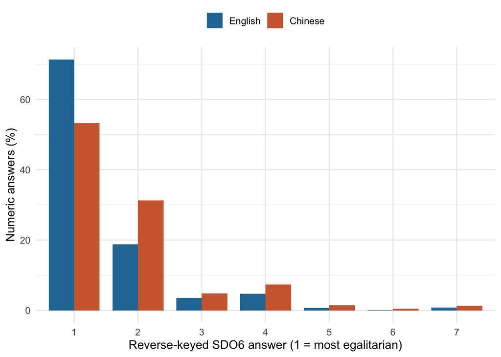

```r
ggplot(distribution, aes(factor(score), percent, fill = language)) +
  geom_col(position = "dodge", width = .8) +
  scale_fill_manual(values = c(en = "#2878A5", zh = "#CF683D"),
                    labels = c(en = "English", zh = "Chinese")) +
  labs(x = "Reverse-keyed SDO6 answer (1 = most egalitarian)",
       y = "Numeric answers (%)", fill = NULL) +
  theme_minimal(base_size = 12) + theme(legend.position = "top")
```

### 4.1 Chi-square statistic with model-level language swaps

To give the two languages identical item/run coverage, restrict this additional test to the **2144 complete pairs**. Within each model, count the answers at each of the seven scale points in each language. On every permutation, independently decide for each model whether to swap its **entire** English and Chinese profiles, retaining all dependence among its items and runs. Use 99,999 random swaps with a fixed seed.

For equal row totals, Pearson’s statistic can be calculated as sum over categories of `(Chinese count - English count)^2 / combined count`. The code uses that identity for speed. Its P value comes from the model-level permutation distribution, **not a chi-square reference distribution with six degrees of freedom**. It is an omnibus test: a significant result establishes a distribution difference, not its direction.

This procedure assumes that, under the null, each model’s two complete language profiles are exchangeable and swaps can be chosen independently across models. It conditions on the fixed 16 items and complete numeric pairs. Missingness depending on language can still bias a complete-pair comparison. Related model families may also violate independence across endpoints; the test does not justify inference to all possible LLMs or all possible questionnaire items.

```r
models <- sort(unique(paired_answers$model_label))
M <- length(models)
en_counts <- t(vapply(models, function(m) {
  tabulate(as.integer(paired_answers$en[paired_answers$model_label == m]), nbins = 7L)
}, integer(7)))
zh_counts <- t(vapply(models, function(m) {
  tabulate(as.integer(paired_answers$zh[paired_answers$model_label == m]), nbins = 7L)
}, integer(7)))
stopifnot(all(rowSums(en_counts) == rowSums(zh_counts)))
dimnames(en_counts) <- dimnames(zh_counts) <- list(models, as.character(1:7))
category_totals <- colSums(en_counts + zh_counts)
present <- category_totals > 0
count_differences <- zh_counts[, present, drop = FALSE] -
                     en_counts[, present, drop = FALSE]
observed_x2 <- sum(colSums(count_differences)^2 / category_totals[present])

# Verify the statistic against R, but deliberately do not use its pooled P value.
pooled_table <- rbind(en = colSums(en_counts), zh = colSums(zh_counts))[, present]
reference_stat <- suppressWarnings(chisq.test(pooled_table, correct = FALSE)$statistic)
stopifnot(isTRUE(all.equal(observed_x2, unname(reference_stat), tolerance = 1e-8)))

# One sign per model per permutation; all of its answers move together.
set.seed(20261025)
swaps <- matrix(sample(c(-1, 1), B_perm * M, replace = TRUE), nrow = B_perm, ncol = M)
permuted_count_differences <- swaps %*% count_differences
permuted_x2 <- rowSums(sweep(permuted_count_differences^2, 2,
                            category_totals[present], FUN = "/"))
exceedances <- sum(permuted_x2 >= observed_x2 - 1e-10)
omnibus_p <- (exceedances + 1) / (B_perm + 1)
omnibus <- tibble(test = "Seven-category distribution: model-level swaps",
                  complete_pairs = nrow(paired_answers), n_models = M,
                  pearson_x2_statistic = observed_x2, permutations = B_perm,
                  exceedances = exceedances, p = omnibus_p,
                  monte_carlo_se_approx = sqrt(omnibus_p * (1 - omnibus_p) / (B_perm + 1)))
save_csv(as.data.frame(as.table(pooled_table)), "complete_pair_distribution_counts.csv")
show_table(omnibus |> select(-test, -monte_carlo_se_approx))
```

| complete_pairs | n_models | pearson_x2_statistic | permutations | exceedances | p |
| --- | --- | --- | --- | --- | --- |
| 2144 | 27 | 153.4579 | 99999 | 0 | 1e-05 |

### 4.2 Which features changed?

Four follow-ups describe the interpretation in Section 3.2: choosing the most egalitarian option (1), using either endpoint (1 or 7), mean distance from the midpoint (`abs(score - 4)`), and choosing the hierarchy-endorsing side (5-7). For each model, calculate these summaries on the same complete pairs and then average their Chinese-minus-English differences across models. A negative endpoint or distance difference indicates less extreme responding in Chinese.

Two-sided permutation P values use the same whole-model swaps. A bootstrap resamples entire models, preserving each English/Chinese pair, for basic bootstrap pointwise 95% confidence intervals. Proportion effects and their intervals are converted to percentage points. The Holm family contains the omnibus test plus these four follow-ups. It does not retrospectively replace the manuscript’s existing multiple-testing registry.

```r
features <- list(
  most_egalitarian_option = function(x) as.numeric(x == 1),
  either_endpoint = function(x) as.numeric(x %in% c(1, 7)),
  distance_from_midpoint = function(x) abs(x - 4),
  hierarchy_endorsing_side = function(x) as.numeric(x >= 5)
)
feature_data <- lapply(names(features), function(name) {
  f <- features[[name]]
  paired_answers |>
    group_by(model_label) |>
    summarise(en = mean(f(en)), zh = mean(f(zh)), .groups = "drop") |>
    mutate(feature = name, difference = zh - en) |>
    arrange(match(model_label, models))
})
names(feature_data) <- names(features)
set.seed(20261026)
boot_index <- matrix(sample.int(M, B_boot * M, replace = TRUE), nrow = B_boot, ncol = M)

feature_results <- bind_rows(lapply(names(feature_data), function(name) {
  d <- feature_data[[name]]
  delta <- d$difference
  stopifnot(identical(d$model_label, models))
  estimate <- mean(delta)
  permuted <- drop(swaps %*% delta) / M
  p <- (1 + sum(abs(permuted) >= abs(estimate) - 1e-12)) / (B_perm + 1)
  boot_means <- rowMeans(matrix(delta[boot_index], nrow = B_boot, ncol = M))
  # Basic bootstrap interval: reflect the bootstrap quantiles around the estimate.
  ci <- 2 * estimate - unname(quantile(boot_means, c(.975, .025)))
  multiplier <- if (name == "distance_from_midpoint") 1 else 100
  tibble(feature = name,
         unit = if (multiplier == 100) "percentage points" else "scale points",
         mean_en = multiplier * mean(d$en), mean_zh = multiplier * mean(d$zh),
         difference_zh_minus_en = multiplier * estimate,
         ci_low = multiplier * ci[1], ci_high = multiplier * ci[2], p = p)
}))
adjusted <- p.adjust(c(omnibus$p, feature_results$p), method = "holm")
omnibus$p_holm <- adjusted[1]
feature_results$p_holm <- adjusted[-1]
save_csv(omnibus, "clustered_distribution_test.csv")
save_csv(feature_results, "response_feature_tests.csv")
save_csv(bind_rows(feature_data), "response_features_by_model.csv")
show_table(feature_results |> transmute(
  Feature = recode(feature,
    most_egalitarian_option = "Most egalitarian option (%)",
    either_endpoint = "Either endpoint (%)",
    distance_from_midpoint = "Distance from midpoint (points)",
    hierarchy_endorsing_side = "Hierarchy-endorsing side (%)"),
  English = mean_en, Chinese = mean_zh, `ZH - EN` = difference_zh_minus_en,
  `95% CI` = sprintf("[%.2f, %.2f]", ci_low, ci_high), p = p, p_holm = p_holm),
  digits = 2)
```

| Feature | English | Chinese | ZH - EN | 95% CI | p | p_holm |
| --- | --- | --- | --- | --- | --- | --- |
| Most egalitarian option (%) | 71.36 | 53.13 | -18.23 | [-22.50, -13.86] | 1e-05 | 5e-05 |
| Either endpoint (%) | 72.21 | 54.49 | -17.71 | [-21.93, -13.32] | 1e-05 | 5e-05 |
| Distance from midpoint (points) | 2.59 | 2.33 | -0.25 | [-0.32, -0.18] | 1e-05 | 5e-05 |
| Hierarchy-endorsing side (%) | 1.69 | 3.32 | 1.63 | [-0.27, 3.21] | 0.0855 | 0.0855 |

An insignificant hierarchy-side comparison would **not** establish equivalence between languages. Describe those responses as rare if the percentages support that statement; do not write that they are statistically unchanged without a separately justified equivalence margin and test. Likewise, an aggregate shift does not imply that every model/item pair stayed on the same side.

## 5 Suggested reporting

The following sentences are generated from this run. The first reports the existing score hypothesis; the second addresses the added Fig. 2A test.

```r
main_sentence <- sprintf(
  paste0("SDO6 scores were higher in Chinese than in English for %d of %d models. ",
         "The mean within-model difference was %.2f scale points (Chinese minus English; ",
         "95%% CI [%.2f, %.2f]; two-sided paired t test across models, t(%d) = %.2f, %s)."),
  primary$higher_in_zh, primary$n_models, primary$difference_zh_minus_en,
  primary$ci_low, primary$ci_high, primary$df, primary$t, p_text(primary$p))
distribution_sentence <- sprintf(
  paste0("In an exploratory comparison restricted to %s model-item-run pairs with numeric ",
         "answers in both languages, the seven-category response distributions %s ",
         "(Pearson chi-square statistic = %.2f; %s permutations swapping entire language ",
         "profiles within models; unadjusted %s; Holm-adjusted %s across five follow-up tests)."),
  format(nrow(paired_answers), big.mark = ","),
  if (omnibus$p_holm < .05) "differed" else "did not differ significantly",
  omnibus$pearson_x2_statistic, format(B_perm, big.mark = ","),
  p_text(omnibus$p), p_text(omnibus$p_holm))
reporting_text <- c(main_sentence, "", distribution_sentence, "",
  paste0("Interpretation: the mean score comparison concerns these tested model endpoints ",
         "and these two SDO6 versions. A language-version difference alone cannot distinguish ",
         "response style, translation/label effects, or an attitude difference."))
writeLines(reporting_text, file.path(out_dir, "suggested_results_text.txt"))
cat(paste(reporting_text, collapse = "\n\n"))
```

SDO6 scores were higher in Chinese than in English for 26 of 27 models. The mean within-model difference was 0.31 scale points (Chinese minus English; 95% CI [0.21, 0.42]; two-sided paired t test across models, t(26) = 6.21, P < .001).

In an exploratory comparison restricted to 2,144 model-item-run pairs with numeric answers in both languages, the seven-category response distributions differed (Pearson chi-square statistic = 153.46; 99,999 permutations swapping entire language profiles within models; unadjusted P < .001; Holm-adjusted P < .001 across five follow-up tests).

Interpretation: the mean score comparison concerns these tested model endpoints and these two SDO6 versions. A language-version difference alone cannot distinguish response style, translation/label effects, or an attitude difference.

The score test already supplies statistical support for a lower English SDO6 score. Prefer **“the models gave more egalitarian responses in English”** to a claim about an intrinsic attitude. Only one Chinese translation was tested.

The supplied supplementary information already reports the paired score test in Supplementary Table S4, together with analyses of distance from the midpoint and endpoint responding. The present notebook reproduces the score comparison from the raw data and adds a direct seven-category distribution comparison. Its new follow-up tests use complete run/item pairs and whole-model swaps, so they need not numerically match those earlier analyses.

## 6 Assumptions and reproducibility

- The paired t test assumes independent model differences and approximately normal sampling behavior for their mean. The sign test and complete-pair distribution test provide complementary checks with different null hypotheses.
- The endpoints were selected rather than randomly sampled. Models from the same developer may be related. Report the result for this tested set; these analyses do not model dependence between related endpoints.
- Items and language versions are fixed here. Generalizing to a population of items would require an appropriate crossed model and measurement assumptions.
- The runs are replicate labels, not paired random seeds or matched time points.
- A change in observed scale scores is not sufficient evidence that the latent attitude is measured equivalently across the two versions.
- The permutation P values include the observed configuration through the `(exceedances + 1)/(B + 1)` correction and are never reported as zero.
- The bootstrap intervals are pointwise, not simultaneous intervals. Follow-up conclusions use the Holm-adjusted P values in the exported tables.

Method references: [R paired t-test documentation](https://stat.ethz.ch/R-manual/R-devel/library/stats/html/t.test.html), [R chi-square documentation](https://stat.ethz.ch/R-manual/R-devel/library/stats/html/chisq.test.html), and [Winkler et al. (2014), permutation inference and exchangeability blocks](https://doi.org/10.1016/j.neuroimage.2014.01.060).

| input | md5 | permutation_seed | bootstrap_seed | permutations | bootstrap_resamples |
| --- | --- | --- | --- | --- | --- |
| Results/SDO_VSA_Results_20260830.csv | 7d7778dff219e71ebb4fca7273883a74 | 20261025 | 20261026 | 99999 | 20000 |